# Forecasting Competition Final Report

Lauren Shohan & Cecilia Liang  
GitHub Repository: https://github.com/jingxliang14/ShohanLiang_ENV797_TSA_ForecastCompetition_S26  
April.25th

# Data Import & Wrangling

```r
humidity <- read_excel("~/R/ShohanLiang_ENV797_TSA_ForecastCompetition_S26/relative_humidity.xlsx")

temperature <- read_excel("~/R/ShohanLiang_ENV797_TSA_ForecastCompetition_S26/temperature.xlsx")

load <- read_excel("~/R/ShohanLiang_ENV797_TSA_ForecastCompetition_S26/load.xlsx")
```

```r
load_daily <- load %>%
  select(date, h1:h24) %>%
  pivot_longer(cols = h1:h24,
               names_to = "hour",
               values_to = "load") %>%
  group_by(date) %>%
  summarise(daily_load = mean(load, na.rm = TRUE))


temp_daily <- temperature %>%
  pivot_longer(cols = starts_with("t_ws"),
               names_to  = "station",
               values_to = "temp") %>%
  group_by(date) %>%
  summarise(daily_temp = mean(temp, na.rm = TRUE))

humi_daily <- humidity %>%
  group_by(date) %>%
  summarise(humi_daily = mean(c_across(starts_with("rh_ws")), na.rm = TRUE))
```

```r
daily_data <- load_daily %>%
  left_join(temp_daily, by = "date") %>%
  left_join(humi_daily,  by = "date") %>%
  arrange(date)

summary(daily_data)
```

```
##       date                       daily_load     daily_temp      humi_daily
##  Min.   :2005-01-01 00:00:00   Min.   :2247   Min.   :21.39   Min.   :27.10
##  1st Qu.:2006-08-16 18:00:00   1st Qu.:2798   1st Qu.:48.53   1st Qu.:61.12
##  Median :2008-03-31 12:00:00   Median :3506   Median :61.90   Median :69.83
##  Mean   :2008-03-31 12:00:00   Mean   :3629   Mean   :60.44   Mean   :68.56
##  3rd Qu.:2009-11-14 06:00:00   3rd Qu.:4211   3rd Qu.:74.12   3rd Qu.:77.01
##  Max.   :2011-06-30 00:00:00   Max.   :7897   Max.   :87.09   Max.   :94.95
```

```r
train <- daily_data %>%
  filter(date <= as.Date("2010-06-30"))

val <- daily_data %>%
  filter(date >= as.Date("2010-07-01") & date <= as.Date("2010-07-31"))

train_msts <- msts(
  train$daily_load,
  seasonal.periods = c(7, 365.25),
  start = c(2005, 1)
)
```

We evaluated several forecasting approaches and selected the five best-performing models based on validation RMSE: Seasonal Naive, TBATS, STLF, ARIMAX, and an ensemble model.

# Model Fit

## SNAIVE

```r
snaive_fit <- snaive(train_msts, h = 31)

snaive_acc <- accuracy(snaive_fit, val$daily_load)
snaive_acc
```

```
##                     ME     RMSE      MAE       MPE     MAPE     MASE      ACF1
## Training set  37.31665 949.3637 705.9425 -2.170041 19.28918 2.040409 0.7418106
## Test set     606.47849 950.3533 837.1102 12.348224 19.35913 2.419527        NA
```

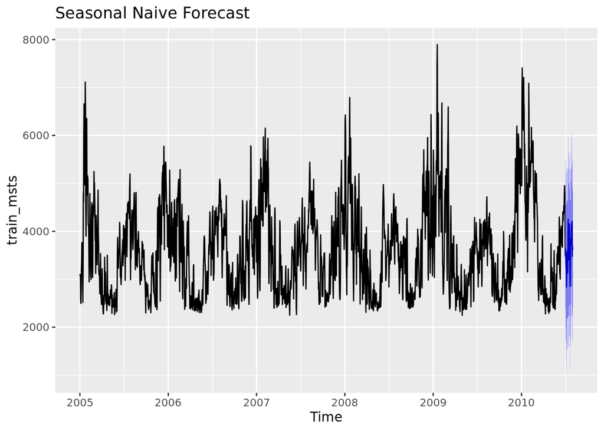

```r
autoplot(snaive_fit) + ggtitle("Seasonal Naive Forecast")
```

## TBATS

The TBATS model was fitted to the multi-seasonal time series (train_msts) to capture both weekly (7-day) and annual (365.25-day) seasonal patterns. A 31-day forecast was generated and compared against the validation set.

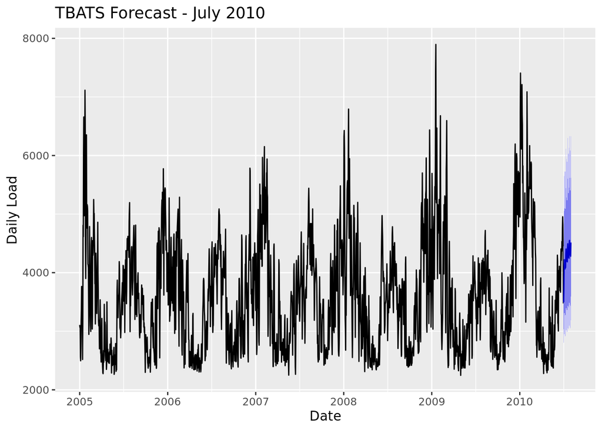

```r
TBATS_fit   <- tbats(train_msts)
TBATS_for   <- forecast(TBATS_fit, h = 31)

autoplot(TBATS_for) +
  ggtitle("TBATS Forecast - July 2010") +
  xlab("Date") + ylab("Daily Load")
```

```r
accuracy(TBATS_for, val$daily_load)
```

```
##                     ME     RMSE      MAE        MPE      MAPE      MASE
## Training set  29.72854 423.4180 313.5971 -0.3367294  8.519267 0.9064001
## Test set     -37.89045 578.1685 444.7257 -3.0103070 11.342232 1.2854054
##                    ACF1
## Training set 0.02248885
## Test set             NA
```

## STLF

The STLF approach decomposed the load series into seasonal and non-seasonal components using the multi-seasonal structure of train_msts. The seasonally adjusted series was then modeled using exponential smoothing (ETS), and the seasonal component was added back to produce forecasts. A 31-day forecast was evaluated against July 2010 to assess its short-term predictive performance.

```r
STLF_for <- stlf(train_msts, h = 31, method = "ets")
accuracy(STLF_for, val$daily_load)
```

```
##                       ME     RMSE      MAE        MPE      MAPE      MASE
## Training set   0.6562383 372.4997 274.6701 -0.4702127  7.569894 0.7938881
## Test set     168.5228883 705.1976 590.3347  1.7013025 14.493213 1.7062637
##                    ACF1
## Training set 0.08022665
## Test set             NA
```

## ARIMAX

An ARIMA(0,1,5) model was fitted to the training load series with external regressors. Fourier terms (K = c(3, 10)) were used to represent weekly and annual seasonality, while daily temperature and humidity were included as covariates. Future Fourier terms and observed weather data from the validation period were used to generate a 31-day forecast. This model explicitly incorporated weather effects alongside temporal dynamics.

```r
K_vec <- c(3, 10)

fourier_train <- fourier(train_msts, K = K_vec)

xreg_train <- cbind(
  fourier_train,
  temp = train$daily_temp,
  humi = train$humi_daily
)

ARIMAX_fit <- Arima(
  train$daily_load,
  order = c(0, 1, 5),
  xreg  = xreg_train
)

fourier_val <- fourier(train_msts, K = K_vec, h = 31)

xreg_val <- cbind(
  fourier_val,
  temp = val$daily_temp,
  humi = val$humi_daily
)

ARIMAX_for <- forecast(ARIMAX_fit, xreg = xreg_val, h = 31)
accuracy(ARIMAX_for, val$daily_load)
```

```
##                     ME     RMSE      MAE        MPE      MAPE      MASE
## Training set  7.431512 358.5818 277.5325 -0.7456654  7.900923 0.8021611
## Test set     -1.161184 700.8879 545.6696 -2.5556391 13.813931 1.5771669
##                     ACF1
## Training set 0.001477354
## Test set              NA
```

## Ensemble forecast

```r
ensemble_val <- (
  as.numeric(TBATS_for$mean) +
  as.numeric(STLF_for$mean) +
  as.numeric(NNETAR_for$mean)
) / 3

accuracy(ensemble_val, val$daily_load)
```

[output not shown]

```
##                ME     RMSE      MAE      MPE     MAPE
## Test set 300.5394 705.0529 599.7525 4.972796 14.21837
```

```r
get_metrics <- function(forecast_obj, actual, name) {

  # If it's a forecast object
  if ("forecast" %in% class(forecast_obj)) {
    acc <- accuracy(forecast_obj, actual)

    tibble(
      model = name,
      RMSE  = acc["Test set", "RMSE"],
      MAE   = acc["Test set", "MAE"],
      MAPE  = acc["Test set", "MAPE"]
    )

  } else {
    # If it's a numeric vector (like ensemble)
    tibble(
      model = name,
      RMSE  = sqrt(mean((forecast_obj - actual)^2)),
      MAE   = mean(abs(forecast_obj - actual)),
      MAPE  = mean(abs((forecast_obj - actual) / actual)) * 100
    )
  }
}


model_results <- bind_rows(
  get_metrics(snaive_fit,  val$daily_load, "SNAIVE"),
  get_metrics(TBATS_for,   val$daily_load, "TBATS"),
  get_metrics(STLF_for,    val$daily_load, "STLF"),
  get_metrics(ARIMAX_for,  val$daily_load, "ARIMAX"),
  get_metrics(ensemble_val, val$daily_load, "ENSEMBLE")
)

model_results %>% arrange(RMSE)
```

```
## # A tibble: 5 × 4
##   model     RMSE   MAE  MAPE
##   <chr>    <dbl> <dbl> <dbl>
## 1 TBATS     578.  445.  11.3
## 2 ARIMAX    701.  546.  13.8
## 3 ENSEMBLE  705.  600.  14.2
## 4 STLF      705.  590.  14.5
## 5 SNAIVE    950.  837.  19.4
```

# Model Comparison

The models were evaluated using RMSE, MAE, and MAPE on the July 2010 validation set.

TBATS achieved the lowest RMSE, indicating it provided the most accurate forecasts among all models. ARIMAX and STLF also performed well, suggesting that both seasonal structure and external covariates contribute to predictive performance. The Seasonal Naive model performed substantially worse, confirming that more sophisticated approaches improve forecast accuracy. The ensemble model did not outperform the best individual model, indicating that averaging did not provide additional gains in this case.